# DMRcaller preparation

Tomato TET3 BS-seq

Javier Antúnez Sánchez

from May 2022 to September 2023

| Chromosome | length (Mbp) |
| --- | --- |
| SL4.0ch00 | 9.6 |
| SL4.0ch01 | 90.9 |
| SL4.0ch02 | 53.5 |
| SL4.0ch03 | 65.3 |
| SL4.0ch04 | 64.5 |
| SL4.0ch05 | 65.3 |
| SL4.0ch06 | 47.3 |
| SL4.0ch07 | 67.9 |
| SL4.0ch08 | 64.0 |
| SL4.0ch09 | 68.5 |
| SL4.0ch10 | 64.8 |
| SL4.0ch11 | 54.4 |
| SL4.0ch12 | 66.7 |

After mapping the BS-seq libraries to the genome with [Bismark](https://github.com/FelixKrueger/Bismark#bismark) and before calling DMRs with [DMRcaller](https://www.bioconductor.org/packages/release/bioc/vignettes/DMRcaller/inst/doc/DMRcaller.pdf) it is needed to check some characteristics of you methylation data to decide with method for DMR caller can be used. The parameters to check are:

- Cytosine read coverage
- Spatial correlation of Methylation levels between close cytosines

After this you can try different methods of DMRcaller and different parameters to select the optimal for your case. The methods I tested are:

- Noise filter
- Bins
- Replicas (with Bins)

Inside each method it is useful to test the parameters of DMRcaller to decide the size of windows or bins and the minimun proportion difference to call a region DMR.

This decisions will probably be different for the different contexts (CG, CHG, and CHH) as they behave biologically in different ways.

As doing these test for the whole genome would take a long time, we use only the smallest chromosome as a sample, which for tomato is chromosome 6 (47 Mbp, see table to the right).

# 1. Methylation statistics

We can calculate **(1)** the read coverage per cytosine and **(2)** the spatial correlation between methylation levels for neighbouring cytosines.

## 1.1. Cytosine Coverage

The first thing to check is the read coverage of cytosines. If sequencing coverage is high enough (most cytosines are covered by at least some reads) you could identify individual DMCs (differentially methylated cytosines), using the Neighbourhood method of DMRcaller with no merging.

Otherwise you can still identify DMRs (differentially methylated regions) using the different methods available in DMRcaller.

### Replicas separated

#### DMRcaller function

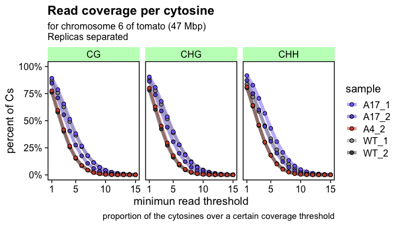

#### dplyr way

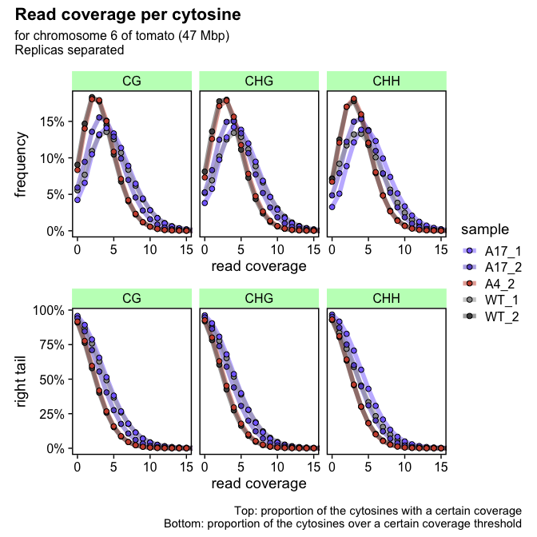

#### Violin and Boxplot

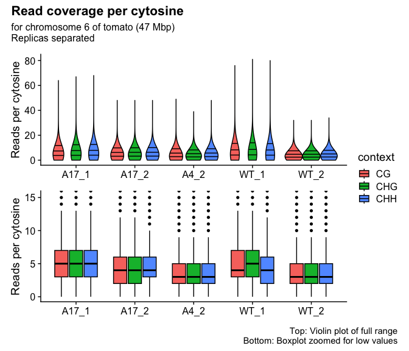

### Replicas pooled

#### DMRcaller function

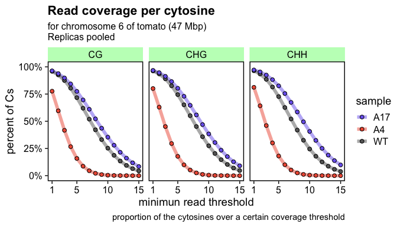

#### dplyr way

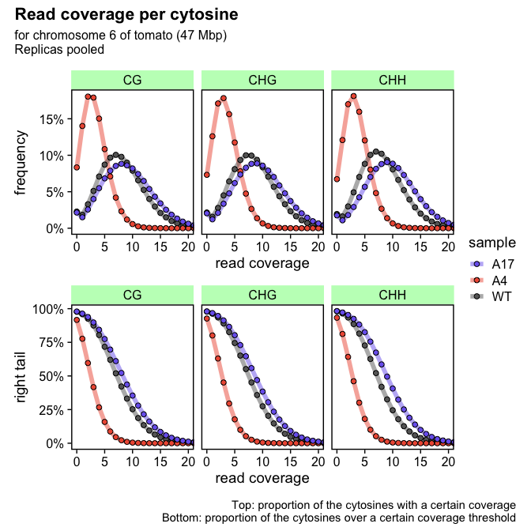

#### Violin and Boxplot

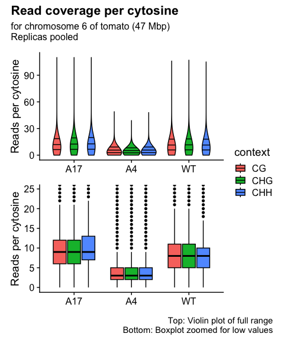

## 1.2. Spatial correlation

The second statistic to test is the Spatial correlation, which measures how much the methylation level of a specific cytosine can predict the methylation level of another cytosine located at a certain distance across the DNA strand. This is informative because it tells us whether the cytosines act as individual units or if their methylation is determined at a region level. Also for computation of DMRs, if there is a good correlation at a specific distance, you can expect cytosines within a window of said distance to behave similarly, and instead of comparing the methylation levels of just one cytosine, you could include the methylation levels of all the cytosines in a region, which provides you with more statistical power as the number of reads mapping to a region will be substantially higher.

The spatial correlation depends on the organism and the context of the cytosine, as they follow different biological mechanisms.

For our data, all samples have a very similar spatial correlation, with A17 (both its replicas and after pooling them) showing less correlation, more noticeable in CG context.

This suggest that we could use the Noise filter method for calling DMRs for CG and CHG, at least for short enough windows, as there is good spatial correlation. However, for CHH the spatial correlation is bad, so ideally we would like to use the Neighbourhood method to identify DMCs or, failing this, the Bins method.

### Replicas separated

#### By sample

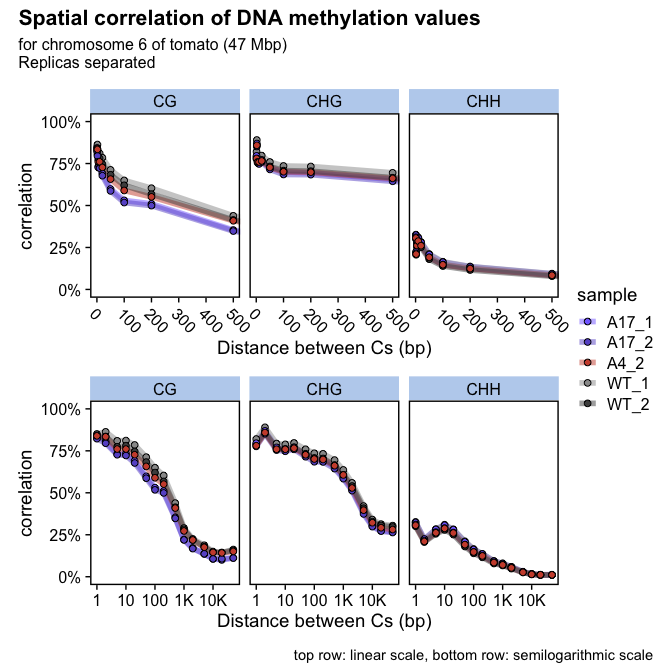

#### By context

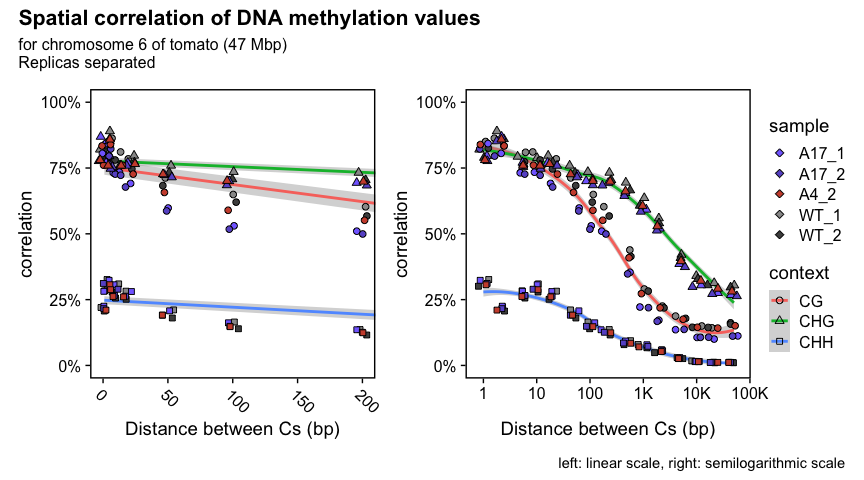

### Replicas pooled

#### By sample

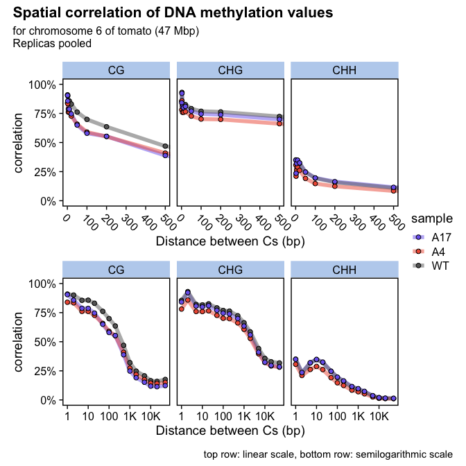

#### By context

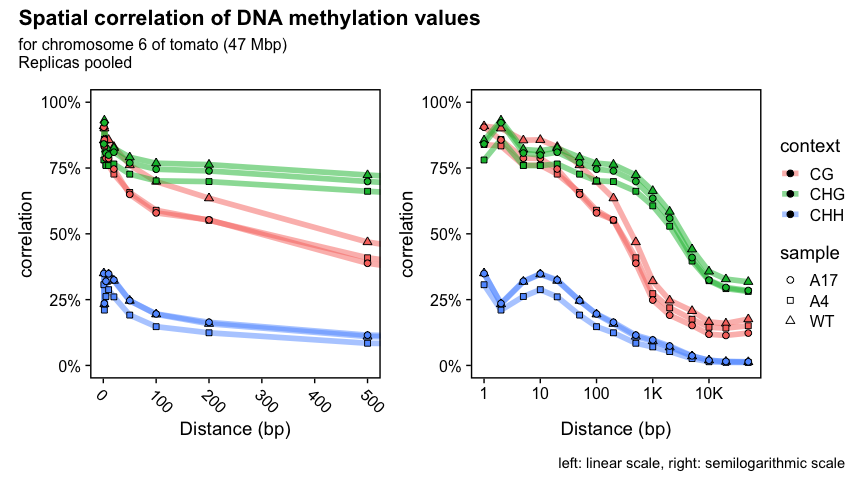

# 2. DMRcaller tests

## 2.1. Noise filter method

Test for noise filtering method for:

- 2 samples: A4 & A17
- 3 contexts: CG, CHG, CHH
- 9 minimum proportion differences: 0.1, 0.2, 0.3, 0.4, 0.5, 0.6, 0.7, 0.8, 0.9
- 9 window sizes: 10, 20, 50, 100, 200, 500, 1000, 2000, 5000

for some reason this parameters where producing almost no DMRs (exclusively CG and very few: up to 10 for A17 loss & 1 for A4 gain).

By tweaking the parameters it seems that the `pValueThreshold` doesn’t work as expected, as even if you relax, the resulting DMRs will still have a very significant p-value, but you will get way more of them.

The conclusion is that for noise filtering I will set the pValue at 0.9 and filter after DMRcaller has finished

### Number

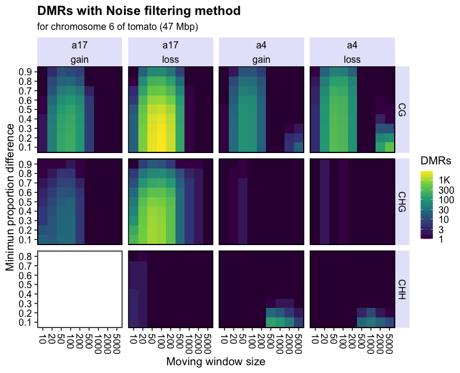

### Length

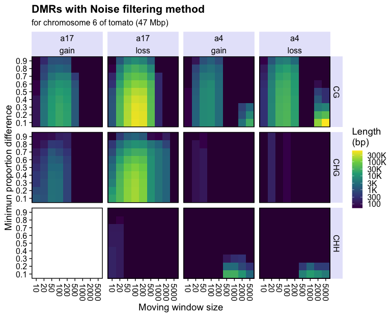

### by window size

#### number

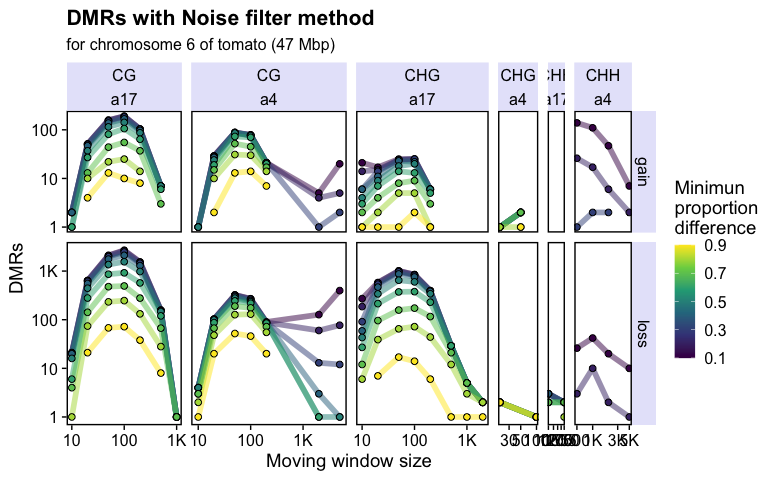

#### length

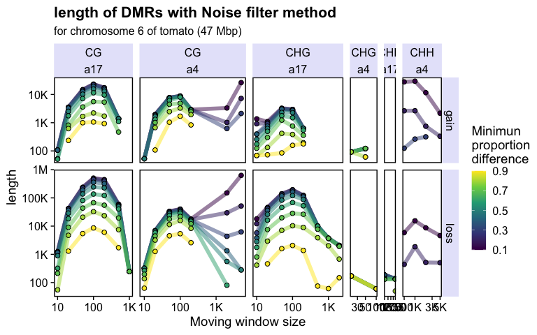

### by minimun proportion difference

#### number

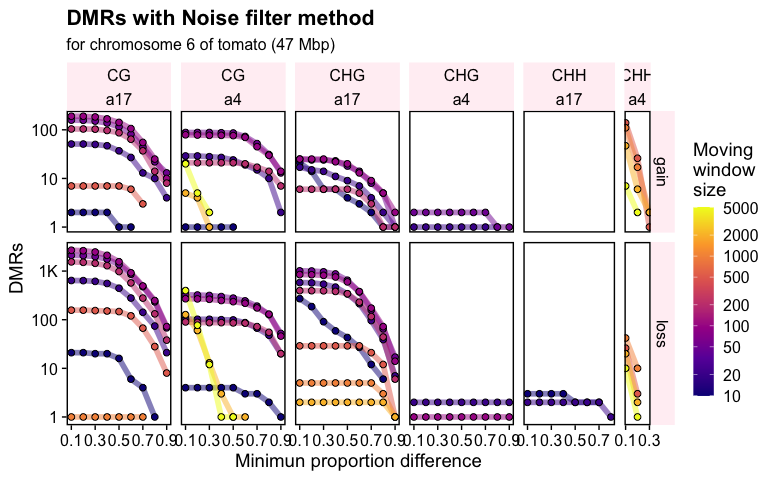

#### length

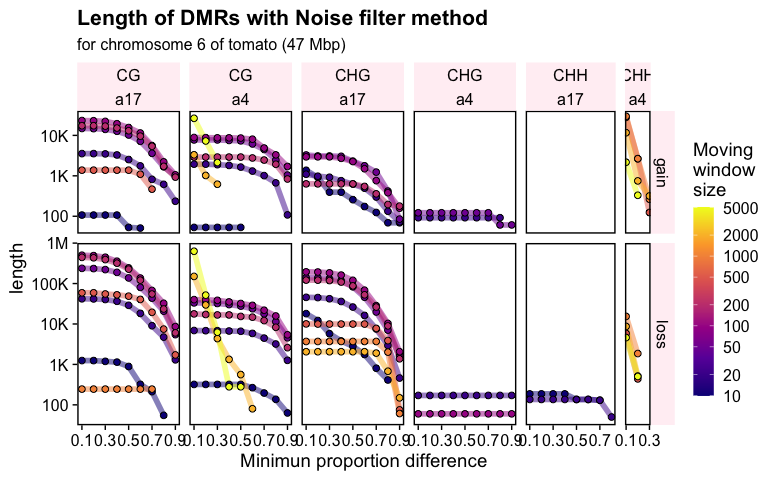

### Volcano plot

#### 100 bp, mpd = 0.1

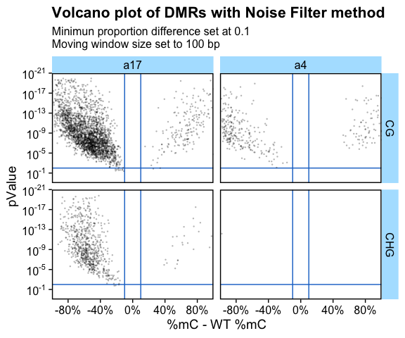

#### 100 bp, mpd = 0.5

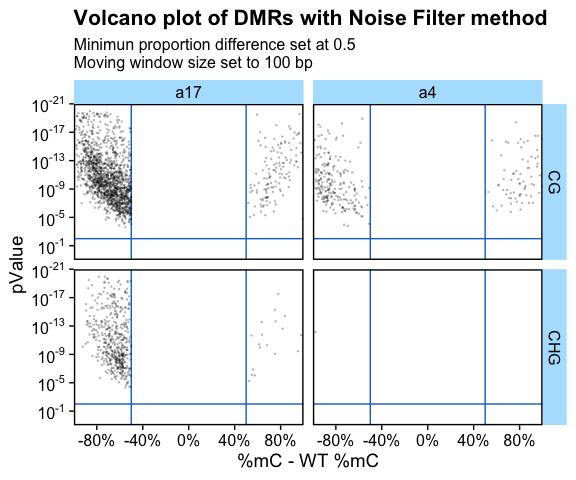

## 2.2. Bins method

Test for bins method for:

- 2 samples: A4 & A17
- 3 contexts: CG, CHG, CHH
- 9 minimum proportion differences: 0.1, 0.2, 0.3, 0.4, 0.5, 0.6, 0.7, 0.8, 0.9
- 9 bin sizes: 10, 20, 50, 100, 200, 500, 1000, 2000, 5000

### Number

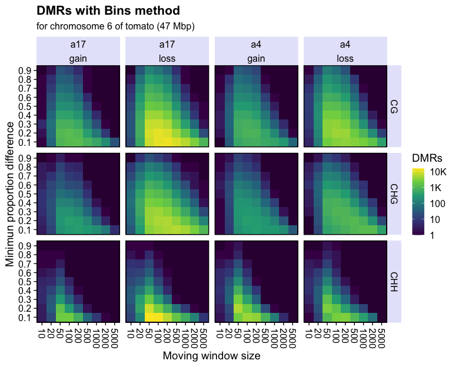

### Length

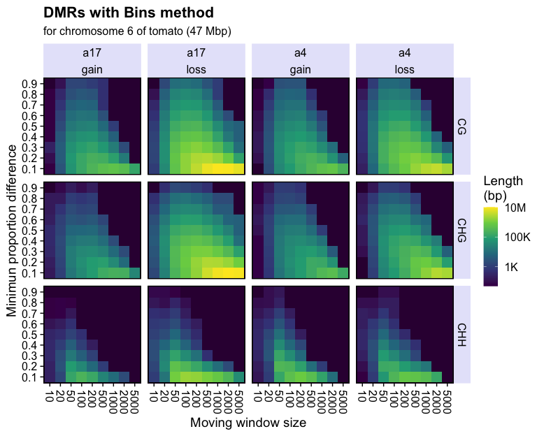

### by window size

#### number

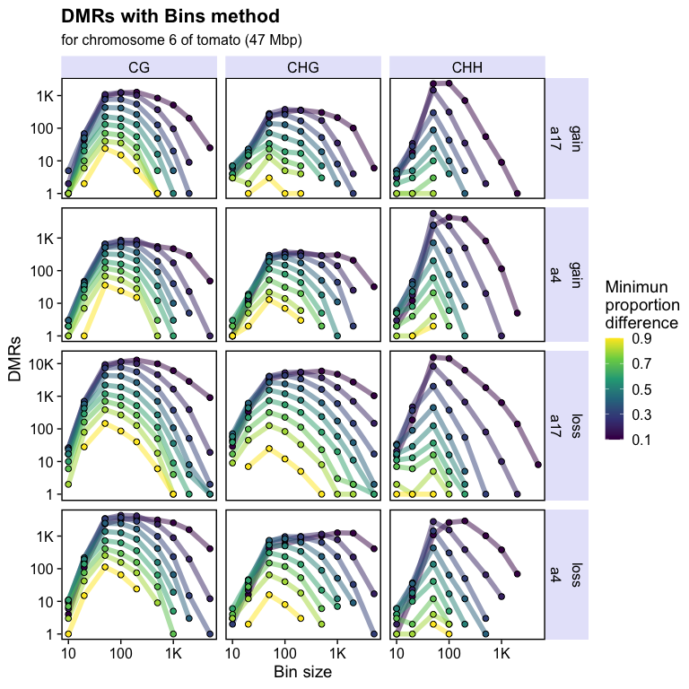

#### length

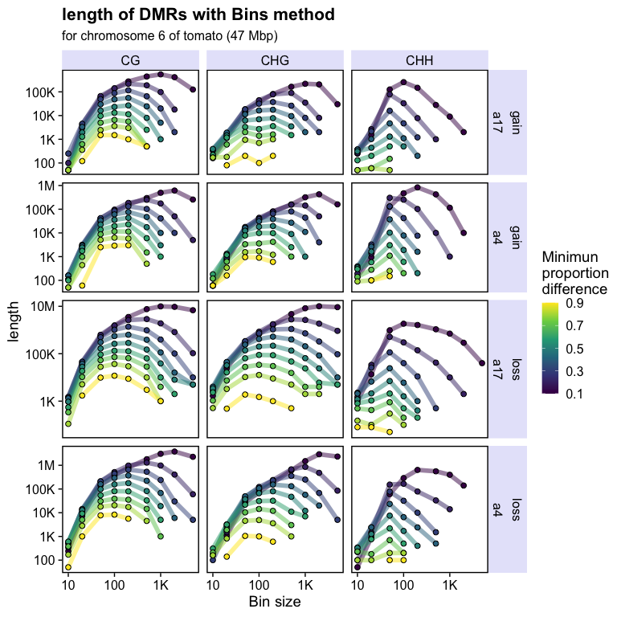

### by minimun proportion difference

For Bin sizes bigger than 20 bp, the length covered by DMRs decreases exponentially with the increase in minimum proportion difference.

#### number

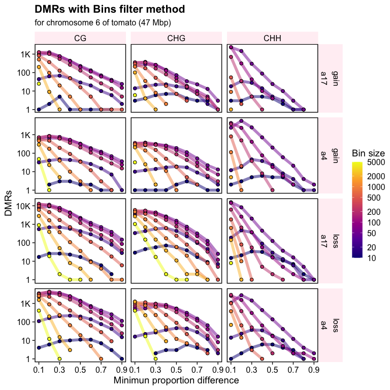

#### length

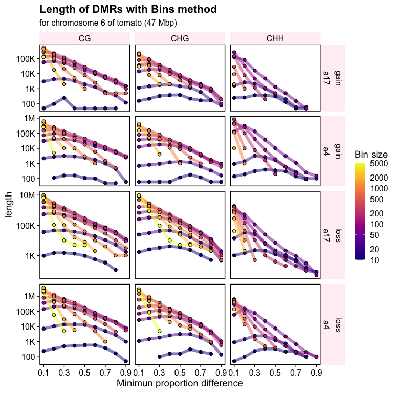

#### length, size = 50

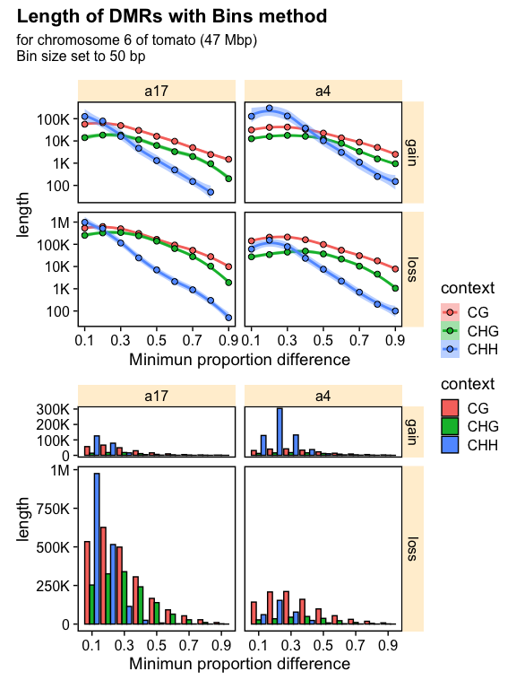

### Volcano plot

#### 50 bp, mpd = 0.1

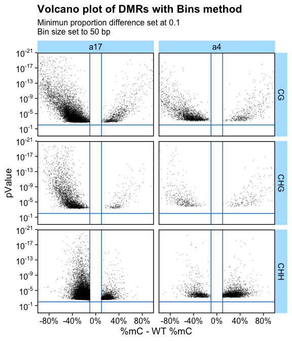

#### 50 bp, mpd = 0.3

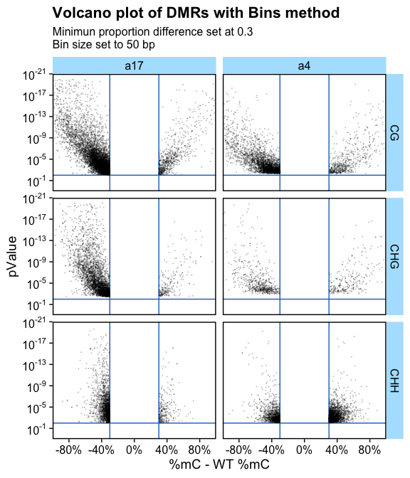

#### 50 bp, mpd = 0.4

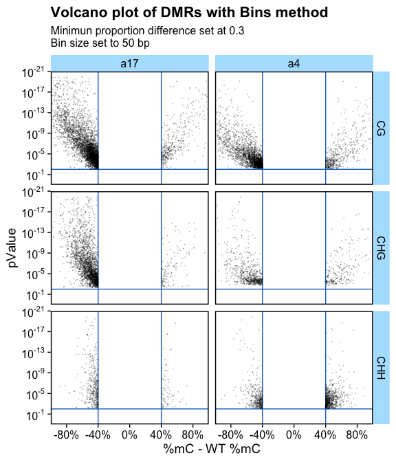

#### 100 bp, mpd = 0.1

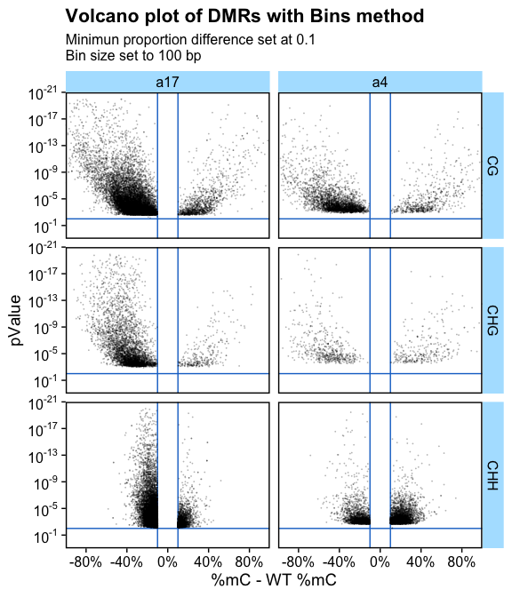